# Precept 9

Emily Nelson

April 6, 2016

```r
set.seed(1990)

library(dplyr)
library(ggplot2)
```

Agenda:

1. Clarification on longitude for project 3
2. Practice with more statistical tests

# Longitude Clarification

Longitude has been transformed in the data that comes with the project. I did this so that plotting would be very simple – I didn’t want people worrying about map projections and such. If you **want** to worry about that stuff, here is the link to NOAA’s site where you can get the untransformed data: ftp://ftp.ncdc.noaa.gov/pub/data/ghcn/daily/ghcnd-stations.txt. Otherwise, just plot longitude by latitude and don’t worry too much about it.

# Categorical Data

Are left-handed people more likely to develop schizophrenia? Research says yes: at a rate five times greater than the right-handed population.

Let’s try detecting this effect.

```r
n = 100

df = data.frame(person = 1:n, hand = rbinom(n, 1, 0.11))

df = df %>%
  group_by(person) %>%
  mutate(diagnosis = ifelse(hand==0, rbinom(1, 1, 0.007),
                            rbinom(1, 1, 0.036))) %>%
  tbl_df()
```

How do we compute the expected values?

What percent of the entire population is diagnosed with schizophrenia? Is left-handed?

What test do we use?

Why is degrees of freedom 1?

# Correlation

## Example 1

Guess the Pearson correlation coefficient (what about Spearman?):

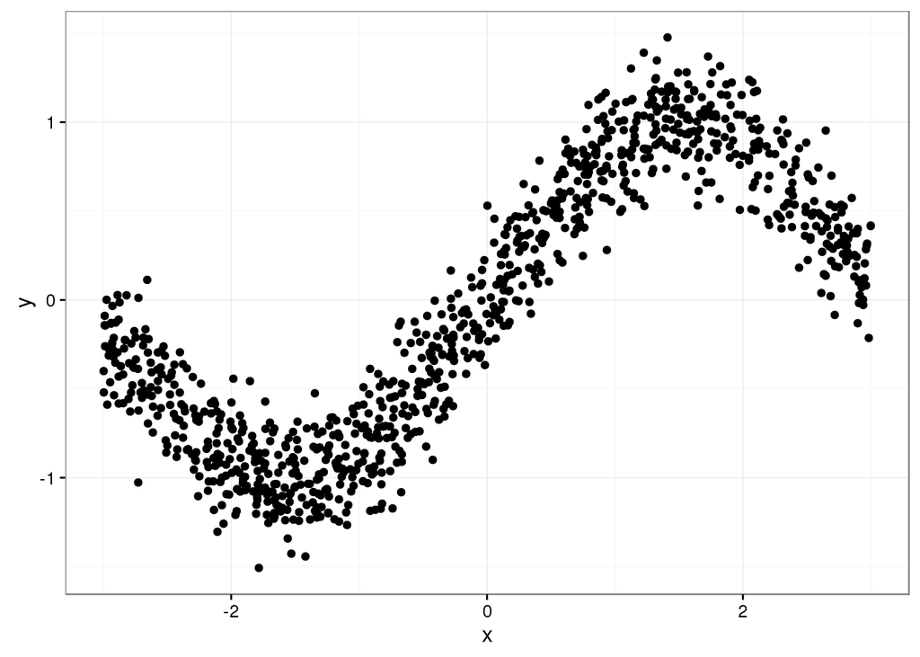

```r
x = runif(1000, -3, 3)
y = sin(x) + rnorm(1000, 0, 0.2)

sin = data.frame(x=x, y=y)
sin %>%
  ggplot(aes(x=x, y=y)) +
  geom_point() +
  theme_bw()
```

Why?

## Example 2

Which will be higher for this dataset, Pearson or Spearman?

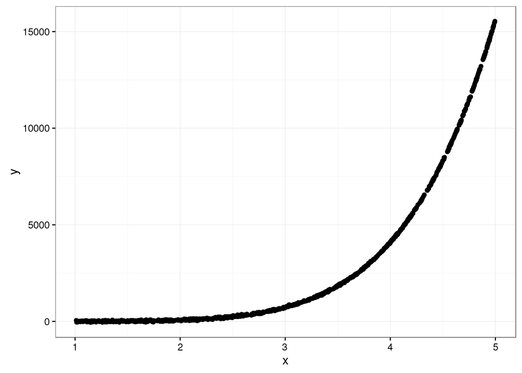

```r
x = runif(1000, 1, 5)
y = x^6 + rnorm(1000, 0, 25)

exp = data.frame(x=x, y=y)
exp %>%
  ggplot(aes(x=x, y=y)) +
  geom_point() +
  theme_bw()
```

What is the advantage of using one of these over the other?